# EC349 Report

2023-11-22

## Introduction

In this project, a dataset containing Yelp reviews was investigated in order to generate predictions for the amount of stars a given user (i) has given a certain business (j). The following report contains a summary on the methods and procedures used as well as an analysis of the results.

## 1. Methodology

The chosen Data Science methodology of this project is CRISP-DM (Cross Industry Standard Process for Data Mining) as its iterative and flexible nature allowed for easy switching between data processing, data cleaning and understanding. Since there were five available datasets in total, a sound understanding of the data in question as well as how Yelp functions was essential before starting the modelling process which is why a methodology heavy on the early stages was chosen. While CRISP-DM is criticised to be outdated and unsuitable for large teams, for this individual project it provided a simple but intuitive structure for understanding the data mining practice. Others claim that CRISP-DM in fact is not flexible at all due to its goal-oriented approach compared to more modern methodologies that allow for more exploratory analysis (Martinez-Plumed et al., 2021). This was not an issue as the goal of this project was simple and focused. During the project, the methodology was applied by iterating between data pre-processing and modelling as well as documenting any data insights in order to plan for the next stages of the process.

## 2. Dataset and preprocessing

For this project, data drawn from five separate data files provided by Yelp for academic purposes was investigated: review-, user-, check-in-, tip- and business data. For review and user data, a simplified, smaller data file was used. For the purposes of analysis, the check-in and tip data files were largely irrelevant and therefore not included in the modelling procedure. Although some errors were found such as wrong date formats or missing values, these were not identified in the variables of interest and thus, correction was not seen as necessary. In a final step, data frames were merged according to “user_id” and “business_id” to aggregate all input of interest in a single file.

## 3. Method

For the modelling procedure, a multinomial logistic regression was implemented. During the data exploration process two explanatory variables were selected: the average star rating given by a user (found in user_data_small) and the average rating received by businesses (found in business_data). These were thought to have the highest predictive power amongst all available variables as they captured both the quality of a business as well as rating behaviours of users. With review ratings ranging between 1 to 5 and user/business averages following the same range, a regression method seemed the most suitable for fitting a linear relationship between outcome and explanatory variables. As the outcome variable is not continuous and is bounded between 1 and 5 ( Yi ∈ {1,2,3,4,5 }), a multinomial logistic regression would approximate the linear relationship well while also handling the review ratings as a factor variable. Additionally, the sigmoid function allows for the transformation of continuous predictors to binary/factor outcomes. Given the simplicity of the model, a more complex method such as random forests would have diminished interpretability without adequate gains in accuracy.

### 3.1 Modelling - most difficult challenge

The most difficult challenge in carrying out the project was in determining the explanatory variables as well as what method to implement. Considering the large volumes of data, the exploratory analysis consisted of visualising the distributions of ratings for both reviews and businesses (see Fig. 1 & 2) to gain a better understanding of what the data looked like, followed by pre-processing the data, merging the relevant data frames and dropping excessive variables. The data cleaning procedure gave me the opportunity to familiarise myself with the data to later on move on to the modelling stage. Existing literature on predicting Yelp ratings demonstrates a variety of ensemble methods in which sentiment analysis is frequently mentioned (Fan and Khademi, 2014; Asghar, 2016). Using sentiment analysis on the text review data would have been a more direct measure for the predictions as the ratings and the text review are essentially the same opinion but expressed in two different ways. However, this type of analysis would have been unnecessarily complex which is why I chose to use more indirect measures about the business and the users to predict the ratings. A paper by (Asghar, 2016) puts forward a logistic regression approach as a 5-star classification problem, demonstrating a better predictive power than other models, hence motivating my deployment of a logistic regression.

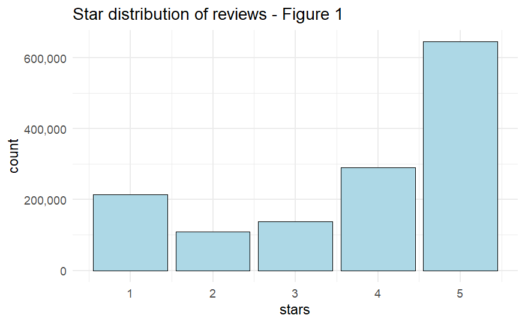

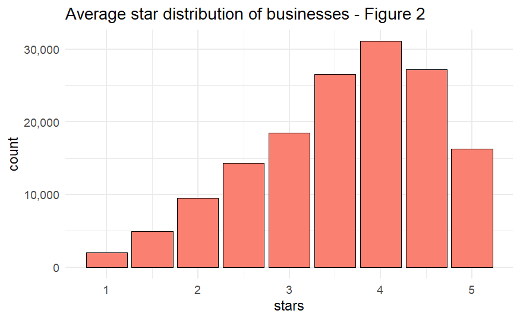

## 4. Analysis of results

The user reviews data was split into training and test data using a 75%,25% split. The predictive results on the test data yielded an accuracy of 54.59% when comparing predictions with actual outcomes in a confusion matrix. There may be several reasons as to why accuracy is low: A common reason is overfitting. If the number of parameters relative to the number of observations were larger, the model may be extrapolating from noise, however this is not the case. The model is not likely to suffer from overfitting due to its simplicity and hence it is expected to be robust to outliers in the data. Conversely, this model is more likely to benefit from added polynomials or interaction terms that more fully capture the mechanisms that play into review ratings. Large values in residual deviance in the training data suggest that the issue may not lie in fitting the data but in the method itself. The relationship between predictors and the outcome variable may be non-linear or correlations sufficiently weak. In this case, a different type of model such as ordered logistic regression could have been more suitable since multinomial logit assumes no rank in the outcomes. Since ratings are ordered, this means that information may have been lost.

## Conclusion

In this project, predictions for Yelp reviews were generated using a multinomial logistic regression. The aim of the project was to predict the number of stars a given user (i) would give a certain business (j) using supervised learning methods. Results are discussed as well as potential reasons for low model accuracy, arguing that multinomial logistic regression may not be the best fit for Yelp review data. Future work could expand on this model through adding more parameters to the regression or switching to an ordered logistic regression.

## References

Asghar, N., 2016. Yelp dataset challenge: Review rating prediction. arXiv preprint arXiv:1605.05362.

Fan, M. and Khademi, M., 2014. Predicting a business star in yelp from its reviews text alone. arXiv preprint arXiv:1401.0864.

Martínez-Plumed, F., Contreras-Ochando, L., Ferri, C., Hernández-Orallo, J., Kull, M., Lachiche, N., Ramírez-Quintana, M.J. and Flach, P., 2019. CRISP-DM twenty years later: From data mining processes to data science trajectories. IEEE Transactions on Knowledge and Data Engineering, 33(8), pp.3048-3061.